# Risk Factor Analysis

## Outcome Variable

**Outcome Variable:** ever_stunted

## Predictor Variables

**Intervention Variable:** enstunt

**Adjustment Set:**

unadjusted

## Stratifying Variables

The analysis was stratified on these variable(s):

- agecat
- studyid
- country

## Data Summary

| agecat | studyid | country | enstunt | ever_stunted | n_cell | n |
| --- | --- | --- | --- | --- | --- | --- |
| 0-6 months | ki0047075b-MAL-ED | BANGLADESH | 0 | 0 | 210 | 257 |
| 0-6 months | ki0047075b-MAL-ED | BANGLADESH | 0 | 1 | 0 | 257 |
| 0-6 months | ki0047075b-MAL-ED | BANGLADESH | 1 | 0 | 0 | 257 |
| 0-6 months | ki0047075b-MAL-ED | BANGLADESH | 1 | 1 | 47 | 257 |
| 0-6 months | ki0047075b-MAL-ED | BRAZIL | 0 | 0 | 170 | 191 |
| 0-6 months | ki0047075b-MAL-ED | BRAZIL | 0 | 1 | 0 | 191 |
| 0-6 months | ki0047075b-MAL-ED | BRAZIL | 1 | 0 | 0 | 191 |
| 0-6 months | ki0047075b-MAL-ED | BRAZIL | 1 | 1 | 21 | 191 |
| 0-6 months | ki0047075b-MAL-ED | INDIA | 0 | 0 | 173 | 206 |
| 0-6 months | ki0047075b-MAL-ED | INDIA | 0 | 1 | 0 | 206 |
| 0-6 months | ki0047075b-MAL-ED | INDIA | 1 | 0 | 0 | 206 |
| 0-6 months | ki0047075b-MAL-ED | INDIA | 1 | 1 | 33 | 206 |
| 0-6 months | ki0047075b-MAL-ED | NEPAL | 0 | 0 | 155 | 173 |
| 0-6 months | ki0047075b-MAL-ED | NEPAL | 0 | 1 | 0 | 173 |
| 0-6 months | ki0047075b-MAL-ED | NEPAL | 1 | 0 | 0 | 173 |
| 0-6 months | ki0047075b-MAL-ED | NEPAL | 1 | 1 | 18 | 173 |
| 0-6 months | ki0047075b-MAL-ED | PERU | 0 | 0 | 253 | 287 |
| 0-6 months | ki0047075b-MAL-ED | PERU | 0 | 1 | 0 | 287 |
| 0-6 months | ki0047075b-MAL-ED | PERU | 1 | 0 | 0 | 287 |
| 0-6 months | ki0047075b-MAL-ED | PERU | 1 | 1 | 34 | 287 |
| 0-6 months | ki0047075b-MAL-ED | SOUTH AFRICA | 0 | 0 | 234 | 262 |
| 0-6 months | ki0047075b-MAL-ED | SOUTH AFRICA | 0 | 1 | 0 | 262 |
| 0-6 months | ki0047075b-MAL-ED | SOUTH AFRICA | 1 | 0 | 0 | 262 |
| 0-6 months | ki0047075b-MAL-ED | SOUTH AFRICA | 1 | 1 | 28 | 262 |
| 0-6 months | ki0047075b-MAL-ED | TANZANIA, UNITED REPUBLIC OF | 0 | 0 | 105 | 123 |
| 0-6 months | ki0047075b-MAL-ED | TANZANIA, UNITED REPUBLIC OF | 0 | 1 | 0 | 123 |
| 0-6 months | ki0047075b-MAL-ED | TANZANIA, UNITED REPUBLIC OF | 1 | 0 | 0 | 123 |
| 0-6 months | ki0047075b-MAL-ED | TANZANIA, UNITED REPUBLIC OF | 1 | 1 | 18 | 123 |
| 0-6 months | ki1000108-CMC-V-BCS-2002 | INDIA | 0 | 0 | 79 | 97 |
| 0-6 months | ki1000108-CMC-V-BCS-2002 | INDIA | 0 | 1 | 2 | 97 |

[output cut: 352 more lines]

The following strata were considered:

- agecat: 0-24 months, studyid: ki0047075b-MAL-ED, country: BANGLADESH
- agecat: 0-24 months, studyid: ki0047075b-MAL-ED, country: BRAZIL
- agecat: 0-24 months, studyid: ki0047075b-MAL-ED, country: INDIA
- agecat: 0-24 months, studyid: ki0047075b-MAL-ED, country: NEPAL
- agecat: 0-24 months, studyid: ki0047075b-MAL-ED, country: PERU
- agecat: 0-24 months, studyid: ki0047075b-MAL-ED, country: SOUTH AFRICA
- agecat: 0-24 months, studyid: ki0047075b-MAL-ED, country: TANZANIA, UNITED REPUBLIC OF
- agecat: 0-24 months, studyid: ki1000108-CMC-V-BCS-2002, country: INDIA
- agecat: 0-24 months, studyid: ki1000108-IRC, country: INDIA
- agecat: 0-24 months, studyid: ki1000109-EE, country: PAKISTAN
- agecat: 0-24 months, studyid: ki1000109-ResPak, country: PAKISTAN
- agecat: 0-24 months, studyid: ki1000304b-SAS-CompFeed, country: INDIA
- agecat: 0-24 months, studyid: ki1000304b-SAS-FoodSuppl, country: INDIA
- agecat: 0-24 months, studyid: ki1017093-NIH-Birth, country: BANGLADESH
- agecat: 0-24 months, studyid: ki1017093c-NIH-Crypto, country: BANGLADESH
- agecat: 0-24 months, studyid: ki1066203-TanzaniaChild2, country: TANZANIA, UNITED REPUBLIC OF
- agecat: 0-24 months, studyid: ki1101329-Keneba, country: GAMBIA
- agecat: 0-24 months, studyid: ki1112895-Guatemala BSC, country: GUATEMALA
- agecat: 0-24 months, studyid: ki1112895-iLiNS-Zinc, country: BURKINA FASO
- agecat: 0-24 months, studyid: ki1113344-GMS-Nepal, country: NEPAL
- agecat: 0-24 months, studyid: ki1114097-CMIN, country: BANGLADESH
- agecat: 0-24 months, studyid: ki1114097-CMIN, country: BRAZIL
- agecat: 0-24 months, studyid: ki1114097-CMIN, country: GUINEA-BISSAU
- agecat: 0-24 months, studyid: ki1114097-CMIN, country: PERU
- agecat: 0-24 months, studyid: ki1114097-CONTENT, country: PERU
- agecat: 0-24 months, studyid: ki1119695-PROBIT, country: BELARUS
- agecat: 0-24 months, studyid: ki1126311-ZVITAMBO, country: ZIMBABWE
- agecat: 0-24 months, studyid: ki1135781-COHORTS, country: GUATEMALA
- agecat: 0-24 months, studyid: ki1135781-COHORTS, country: INDIA
- agecat: 0-24 months, studyid: ki1135781-COHORTS, country: PHILIPPINES
- agecat: 0-24 months, studyid: ki1148112-LCNI-5, country: MALAWI
- agecat: 0-24 months, studyid: kiGH5241-JiVitA-3, country: BANGLADESH
- agecat: 0-24 months, studyid: kiGH5241-JiVitA-4, country: BANGLADESH
- agecat: 0-6 months, studyid: ki0047075b-MAL-ED, country: BANGLADESH
- agecat: 0-6 months, studyid: ki0047075b-MAL-ED, country: BRAZIL
- agecat: 0-6 months, studyid: ki0047075b-MAL-ED, country: INDIA
- agecat: 0-6 months, studyid: ki0047075b-MAL-ED, country: NEPAL
- agecat: 0-6 months, studyid: ki0047075b-MAL-ED, country: PERU
- agecat: 0-6 months, studyid: ki0047075b-MAL-ED, country: SOUTH AFRICA
- agecat: 0-6 months, studyid: ki0047075b-MAL-ED, country: TANZANIA, UNITED REPUBLIC OF
- agecat: 0-6 months, studyid: ki1000108-CMC-V-BCS-2002, country: INDIA
- agecat: 0-6 months, studyid: ki1000108-IRC, country: INDIA
- agecat: 0-6 months, studyid: ki1000109-EE, country: PAKISTAN
- agecat: 0-6 months, studyid: ki1000109-ResPak, country: PAKISTAN
- agecat: 0-6 months, studyid: ki1000304b-SAS-CompFeed, country: INDIA
- agecat: 0-6 months, studyid: ki1000304b-SAS-FoodSuppl, country: INDIA
- agecat: 0-6 months, studyid: ki1017093-NIH-Birth, country: BANGLADESH
- agecat: 0-6 months, studyid: ki1017093c-NIH-Crypto, country: BANGLADESH
- agecat: 0-6 months, studyid: ki1066203-TanzaniaChild2, country: TANZANIA, UNITED REPUBLIC OF
- agecat: 0-6 months, studyid: ki1101329-Keneba, country: GAMBIA
- agecat: 0-6 months, studyid: ki1112895-Guatemala BSC, country: GUATEMALA
- agecat: 0-6 months, studyid: ki1113344-GMS-Nepal, country: NEPAL
- agecat: 0-6 months, studyid: ki1114097-CMIN, country: BANGLADESH
- agecat: 0-6 months, studyid: ki1114097-CMIN, country: BRAZIL
- agecat: 0-6 months, studyid: ki1114097-CMIN, country: GUINEA-BISSAU
- agecat: 0-6 months, studyid: ki1114097-CMIN, country: PERU
- agecat: 0-6 months, studyid: ki1114097-CONTENT, country: PERU
- agecat: 0-6 months, studyid: ki1119695-PROBIT, country: BELARUS
- agecat: 0-6 months, studyid: ki1126311-ZVITAMBO, country: ZIMBABWE
- agecat: 0-6 months, studyid: ki1135781-COHORTS, country: GUATEMALA
- agecat: 0-6 months, studyid: ki1135781-COHORTS, country: INDIA
- agecat: 0-6 months, studyid: ki1135781-COHORTS, country: PHILIPPINES
- agecat: 0-6 months, studyid: ki1148112-LCNI-5, country: MALAWI
- agecat: 0-6 months, studyid: kiGH5241-JiVitA-3, country: BANGLADESH
- agecat: 0-6 months, studyid: kiGH5241-JiVitA-4, country: BANGLADESH
- agecat: 6-24 months, studyid: ki0047075b-MAL-ED, country: BANGLADESH
- agecat: 6-24 months, studyid: ki0047075b-MAL-ED, country: BRAZIL
- agecat: 6-24 months, studyid: ki0047075b-MAL-ED, country: INDIA
- agecat: 6-24 months, studyid: ki0047075b-MAL-ED, country: NEPAL
- agecat: 6-24 months, studyid: ki0047075b-MAL-ED, country: PERU
- agecat: 6-24 months, studyid: ki0047075b-MAL-ED, country: SOUTH AFRICA
- agecat: 6-24 months, studyid: ki0047075b-MAL-ED, country: TANZANIA, UNITED REPUBLIC OF
- agecat: 6-24 months, studyid: ki1000108-CMC-V-BCS-2002, country: INDIA
- agecat: 6-24 months, studyid: ki1000108-IRC, country: INDIA
- agecat: 6-24 months, studyid: ki1000109-EE, country: PAKISTAN
- agecat: 6-24 months, studyid: ki1000109-ResPak, country: PAKISTAN
- agecat: 6-24 months, studyid: ki1000304b-SAS-CompFeed, country: INDIA
- agecat: 6-24 months, studyid: ki1000304b-SAS-FoodSuppl, country: INDIA
- agecat: 6-24 months, studyid: ki1017093-NIH-Birth, country: BANGLADESH
- agecat: 6-24 months, studyid: ki1017093c-NIH-Crypto, country: BANGLADESH
- agecat: 6-24 months, studyid: ki1066203-TanzaniaChild2, country: TANZANIA, UNITED REPUBLIC OF
- agecat: 6-24 months, studyid: ki1101329-Keneba, country: GAMBIA
- agecat: 6-24 months, studyid: ki1112895-Guatemala BSC, country: GUATEMALA
- agecat: 6-24 months, studyid: ki1112895-iLiNS-Zinc, country: BURKINA FASO
- agecat: 6-24 months, studyid: ki1113344-GMS-Nepal, country: NEPAL
- agecat: 6-24 months, studyid: ki1114097-CMIN, country: BRAZIL
- agecat: 6-24 months, studyid: ki1114097-CMIN, country: GUINEA-BISSAU
- agecat: 6-24 months, studyid: ki1114097-CMIN, country: PERU
- agecat: 6-24 months, studyid: ki1114097-CONTENT, country: PERU
- agecat: 6-24 months, studyid: ki1119695-PROBIT, country: BELARUS
- agecat: 6-24 months, studyid: ki1126311-ZVITAMBO, country: ZIMBABWE
- agecat: 6-24 months, studyid: ki1135781-COHORTS, country: GUATEMALA
- agecat: 6-24 months, studyid: ki1135781-COHORTS, country: INDIA
- agecat: 6-24 months, studyid: ki1135781-COHORTS, country: PHILIPPINES
- agecat: 6-24 months, studyid: ki1148112-LCNI-5, country: MALAWI
- agecat: 6-24 months, studyid: kiGH5241-JiVitA-3, country: BANGLADESH
- agecat: 6-24 months, studyid: kiGH5241-JiVitA-4, country: BANGLADESH

### Dropped Strata

Some strata were dropped due to rare outcomes:

- agecat: 0-6 months, studyid: ki0047075b-MAL-ED, country: BANGLADESH
- agecat: 0-6 months, studyid: ki0047075b-MAL-ED, country: BRAZIL
- agecat: 0-6 months, studyid: ki0047075b-MAL-ED, country: INDIA
- agecat: 0-6 months, studyid: ki0047075b-MAL-ED, country: NEPAL
- agecat: 0-6 months, studyid: ki0047075b-MAL-ED, country: PERU
- agecat: 0-6 months, studyid: ki0047075b-MAL-ED, country: SOUTH AFRICA
- agecat: 0-6 months, studyid: ki0047075b-MAL-ED, country: TANZANIA, UNITED REPUBLIC OF
- agecat: 0-6 months, studyid: ki1000108-CMC-V-BCS-2002, country: INDIA
- agecat: 0-6 months, studyid: ki1000108-IRC, country: INDIA
- agecat: 0-6 months, studyid: ki1000109-EE, country: PAKISTAN
- agecat: 0-6 months, studyid: ki1000109-ResPak, country: PAKISTAN
- agecat: 0-6 months, studyid: ki1000304b-SAS-CompFeed, country: INDIA
- agecat: 0-6 months, studyid: ki1000304b-SAS-FoodSuppl, country: INDIA
- agecat: 0-6 months, studyid: ki1017093-NIH-Birth, country: BANGLADESH
- agecat: 0-6 months, studyid: ki1017093c-NIH-Crypto, country: BANGLADESH
- agecat: 0-6 months, studyid: ki1066203-TanzaniaChild2, country: TANZANIA, UNITED REPUBLIC OF
- agecat: 0-6 months, studyid: ki1101329-Keneba, country: GAMBIA
- agecat: 0-6 months, studyid: ki1112895-Guatemala BSC, country: GUATEMALA
- agecat: 0-6 months, studyid: ki1113344-GMS-Nepal, country: NEPAL
- agecat: 0-6 months, studyid: ki1114097-CMIN, country: BANGLADESH
- agecat: 0-6 months, studyid: ki1114097-CMIN, country: BRAZIL
- agecat: 0-6 months, studyid: ki1114097-CMIN, country: GUINEA-BISSAU
- agecat: 0-6 months, studyid: ki1114097-CMIN, country: PERU
- agecat: 0-6 months, studyid: ki1114097-CONTENT, country: PERU
- agecat: 0-6 months, studyid: ki1119695-PROBIT, country: BELARUS
- agecat: 0-6 months, studyid: ki1126311-ZVITAMBO, country: ZIMBABWE
- agecat: 0-6 months, studyid: ki1135781-COHORTS, country: GUATEMALA
- agecat: 0-6 months, studyid: ki1135781-COHORTS, country: INDIA
- agecat: 0-6 months, studyid: ki1135781-COHORTS, country: PHILIPPINES
- agecat: 0-6 months, studyid: ki1148112-LCNI-5, country: MALAWI
- agecat: 0-6 months, studyid: kiGH5241-JiVitA-3, country: BANGLADESH
- agecat: 0-6 months, studyid: kiGH5241-JiVitA-4, country: BANGLADESH
- agecat: 6-24 months, studyid: ki0047075b-MAL-ED, country: BRAZIL
- agecat: 6-24 months, studyid: ki0047075b-MAL-ED, country: NEPAL
- agecat: 6-24 months, studyid: ki0047075b-MAL-ED, country: TANZANIA, UNITED REPUBLIC OF
- agecat: 6-24 months, studyid: ki1000108-CMC-V-BCS-2002, country: INDIA
- agecat: 6-24 months, studyid: ki1000109-EE, country: PAKISTAN
- agecat: 6-24 months, studyid: ki1000109-ResPak, country: PAKISTAN
- agecat: 6-24 months, studyid: ki1000304b-SAS-FoodSuppl, country: INDIA
- agecat: 6-24 months, studyid: ki1017093c-NIH-Crypto, country: BANGLADESH
- agecat: 6-24 months, studyid: ki1066203-TanzaniaChild2, country: TANZANIA, UNITED REPUBLIC OF
- agecat: 6-24 months, studyid: ki1112895-Guatemala BSC, country: GUATEMALA
- agecat: 6-24 months, studyid: ki1113344-GMS-Nepal, country: NEPAL
- agecat: 6-24 months, studyid: ki1114097-CMIN, country: BRAZIL
- agecat: 6-24 months, studyid: ki1114097-CMIN, country: PERU
- agecat: 6-24 months, studyid: ki1114097-CONTENT, country: PERU
- agecat: 6-24 months, studyid: ki1119695-PROBIT, country: BELARUS
- agecat: 0-24 months, studyid: ki0047075b-MAL-ED, country: BANGLADESH
- agecat: 0-24 months, studyid: ki0047075b-MAL-ED, country: BRAZIL
- agecat: 0-24 months, studyid: ki0047075b-MAL-ED, country: INDIA
- agecat: 0-24 months, studyid: ki0047075b-MAL-ED, country: NEPAL
- agecat: 0-24 months, studyid: ki0047075b-MAL-ED, country: PERU
- agecat: 0-24 months, studyid: ki0047075b-MAL-ED, country: SOUTH AFRICA
- agecat: 0-24 months, studyid: ki0047075b-MAL-ED, country: TANZANIA, UNITED REPUBLIC OF
- agecat: 0-24 months, studyid: ki1000108-CMC-V-BCS-2002, country: INDIA
- agecat: 0-24 months, studyid: ki1000108-IRC, country: INDIA
- agecat: 0-24 months, studyid: ki1000109-EE, country: PAKISTAN
- agecat: 0-24 months, studyid: ki1000109-ResPak, country: PAKISTAN
- agecat: 0-24 months, studyid: ki1000304b-SAS-CompFeed, country: INDIA
- agecat: 0-24 months, studyid: ki1000304b-SAS-FoodSuppl, country: INDIA
- agecat: 0-24 months, studyid: ki1017093-NIH-Birth, country: BANGLADESH
- agecat: 0-24 months, studyid: ki1017093c-NIH-Crypto, country: BANGLADESH
- agecat: 0-24 months, studyid: ki1066203-TanzaniaChild2, country: TANZANIA, UNITED REPUBLIC OF
- agecat: 0-24 months, studyid: ki1112895-Guatemala BSC, country: GUATEMALA
- agecat: 0-24 months, studyid: ki1112895-iLiNS-Zinc, country: BURKINA FASO
- agecat: 0-24 months, studyid: ki1113344-GMS-Nepal, country: NEPAL
- agecat: 0-24 months, studyid: ki1114097-CMIN, country: BANGLADESH
- agecat: 0-24 months, studyid: ki1114097-CMIN, country: BRAZIL
- agecat: 0-24 months, studyid: ki1114097-CMIN, country: GUINEA-BISSAU
- agecat: 0-24 months, studyid: ki1114097-CMIN, country: PERU
- agecat: 0-24 months, studyid: ki1114097-CONTENT, country: PERU
- agecat: 0-24 months, studyid: ki1119695-PROBIT, country: BELARUS
- agecat: 0-24 months, studyid: ki1135781-COHORTS, country: GUATEMALA
- agecat: 0-24 months, studyid: ki1135781-COHORTS, country: INDIA
- agecat: 0-24 months, studyid: ki1135781-COHORTS, country: PHILIPPINES
- agecat: 0-24 months, studyid: ki1148112-LCNI-5, country: MALAWI
- agecat: 0-24 months, studyid: kiGH5241-JiVitA-3, country: BANGLADESH
- agecat: 0-24 months, studyid: kiGH5241-JiVitA-4, country: BANGLADESH

## Methods Detail

We’re interested in the causal parameters $E[Y_a]$ for all values of $a \in \mathcal{A}$. These parameters represent the mean outcome if, possibly contrary to fact, we intervened to set all units to have $A=a$. Under the randomization and positivity assumptions, these are identified by the statistical parameters $\psi_a=E_W[E_{Y|A,W}(Y|A=a,W)]$. In addition, we’re interested in the mean of $Y$, $E[Y]$ under no intervention (the observed mean). We will estimate these parameters by using SuperLearner to fit the relevant likelihood factors – $E_{Y|A,W}(Y|A=a,W)$ and $p(A=a|W)$, and then updating our likelihood fit using a joint TMLE.

For unadjusted analyses ($W=\{\}$), initial likelihoods were estimated using Lrnr_glm to estimate the simple $E(Y|A)$ and Lrnr_mean to estimate $p(A)$. For adjusted analyses, a small library containing Lrnr_glmnet, Lrnr_xgboost, and Lrnr_mean was used.

Having estimated these parameters, we will then use the delta method to estimate relative risks and attributable risks relative to a prespecified baseline level of $A$.

```
##        ever_stunted
## enstunt    0
##       0 5207
##       1  324
```

# Results Detail

## Results Plots

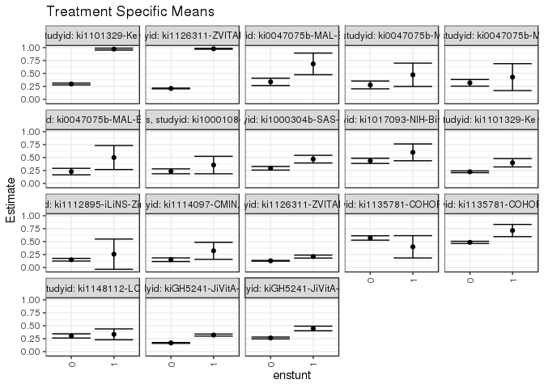

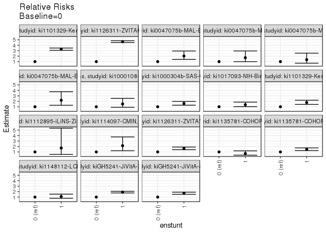

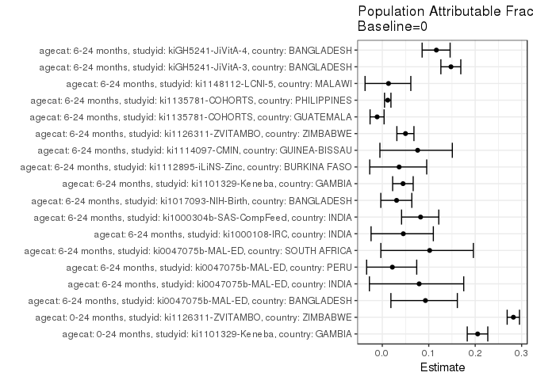

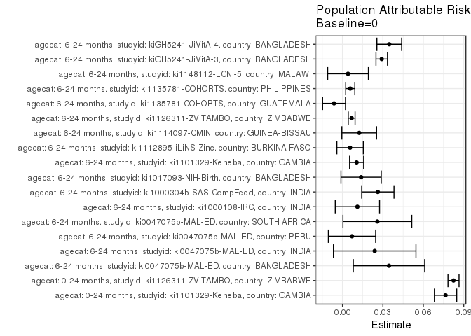

## Results Table

### Parameter: TSM

| agecat | studyid | country | intervention_level | baseline_level | estimate | ci_lower | ci_upper |
| --- | --- | --- | --- | --- | --- | --- | --- |
| 0-24 months | ki1101329-Keneba | GAMBIA | 0 | NA | 0.2961672 | 0.2785571 | 0.3137774 |
| 0-24 months | ki1101329-Keneba | GAMBIA | 1 | NA | 0.9697885 | 0.9513455 | 0.9882316 |
| 0-24 months | ki1126311-ZVITAMBO | ZIMBABWE | 0 | NA | 0.2096618 | 0.2025026 | 0.2168211 |
| 0-24 months | ki1126311-ZVITAMBO | ZIMBABWE | 1 | NA | 0.9759519 | 0.9681911 | 0.9837127 |
| 6-24 months | ki0047075b-MAL-ED | BANGLADESH | 0 | NA | 0.3372093 | 0.2663720 | 0.4080466 |
| 6-24 months | ki0047075b-MAL-ED | BANGLADESH | 1 | NA | 0.6842105 | 0.4746522 | 0.8937688 |
| 6-24 months | ki0047075b-MAL-ED | INDIA | 0 | NA | 0.2773723 | 0.2021627 | 0.3525818 |
| 6-24 months | ki0047075b-MAL-ED | INDIA | 1 | NA | 0.4736842 | 0.2484495 | 0.6989190 |
| 6-24 months | ki0047075b-MAL-ED | PERU | 0 | NA | 0.3186275 | 0.2545411 | 0.3827138 |
| 6-24 months | ki0047075b-MAL-ED | PERU | 1 | NA | 0.4285714 | 0.1687500 | 0.6883929 |
| 6-24 months | ki0047075b-MAL-ED | SOUTH AFRICA | 0 | NA | 0.2280702 | 0.1650144 | 0.2911260 |
| 6-24 months | ki0047075b-MAL-ED | SOUTH AFRICA | 1 | NA | 0.5000000 | 0.2684025 | 0.7315975 |
| 6-24 months | ki1000108-IRC | INDIA | 0 | NA | 0.2337662 | 0.1864309 | 0.2811016 |
| 6-24 months | ki1000108-IRC | INDIA | 1 | NA | 0.3548387 | 0.1861607 | 0.5235167 |
| 6-24 months | ki1000304b-SAS-CompFeed | INDIA | 0 | NA | 0.2921760 | 0.2571001 | 0.3272520 |
| 6-24 months | ki1000304b-SAS-CompFeed | INDIA | 1 | NA | 0.4685315 | 0.3947165 | 0.5423465 |
| 6-24 months | ki1017093-NIH-Birth | BANGLADESH | 0 | NA | 0.4356955 | 0.3858465 | 0.4855445 |
| 6-24 months | ki1017093-NIH-Birth | BANGLADESH | 1 | NA | 0.6000000 | 0.4375041 | 0.7624959 |
| 6-24 months | ki1101329-Keneba | GAMBIA | 0 | NA | 0.2243618 | 0.2070557 | 0.2416679 |
| 6-24 months | ki1101329-Keneba | GAMBIA | 1 | NA | 0.3986014 | 0.3183372 | 0.4788656 |
| 6-24 months | ki1112895-iLiNS-Zinc | BURKINA FASO | 0 | NA | 0.1499593 | 0.1240558 | 0.1758627 |
| 6-24 months | ki1112895-iLiNS-Zinc | BURKINA FASO | 1 | NA | 0.2573529 | -0.0347168 | 0.5494226 |
| 6-24 months | ki1114097-CMIN | GUINEA-BISSAU | 0 | NA | 0.1507538 | 0.1155601 | 0.1859474 |
| 6-24 months | ki1114097-CMIN | GUINEA-BISSAU | 1 | NA | 0.3225806 | 0.1578320 | 0.4873293 |
| 6-24 months | ki1126311-ZVITAMBO | ZIMBABWE | 0 | NA | 0.1295024 | 0.1223389 | 0.1366658 |
| 6-24 months | ki1126311-ZVITAMBO | ZIMBABWE | 1 | NA | 0.2112125 | 0.1823248 | 0.2401003 |
| 6-24 months | ki1135781-COHORTS | GUATEMALA | 0 | NA | 0.5706107 | 0.5281900 | 0.6130314 |
| 6-24 months | ki1135781-COHORTS | GUATEMALA | 1 | NA | 0.4000000 | 0.1850991 | 0.6149009 |
| 6-24 months | ki1135781-COHORTS | PHILIPPINES | 0 | NA | 0.4856614 | 0.4645892 | 0.5067336 |
| 6-24 months | ki1135781-COHORTS | PHILIPPINES | 1 | NA | 0.7142857 | 0.5959396 | 0.8326318 |
| 6-24 months | ki1148112-LCNI-5 | MALAWI | 0 | NA | 0.3027888 | 0.2625613 | 0.3430163 |
| 6-24 months | ki1148112-LCNI-5 | MALAWI | 1 | NA | 0.3333333 | 0.2286279 | 0.4380388 |
| 6-24 months | kiGH5241-JiVitA-3 | BANGLADESH | 0 | NA | 0.1678956 | 0.1594738 | 0.1763175 |
| 6-24 months | kiGH5241-JiVitA-3 | BANGLADESH | 1 | NA | 0.3196656 | 0.2996743 | 0.3396569 |
| 6-24 months | kiGH5241-JiVitA-4 | BANGLADESH | 0 | NA | 0.2635754 | 0.2459280 | 0.2812227 |
| 6-24 months | kiGH5241-JiVitA-4 | BANGLADESH | 1 | NA | 0.4470588 | 0.4023273 | 0.4917904 |

### Parameter: E(Y)

| agecat | studyid | country | intervention_level | baseline_level | estimate | ci_lower | ci_upper |
| --- | --- | --- | --- | --- | --- | --- | --- |
| 0-24 months | ki1101329-Keneba | GAMBIA | NA | NA | 0.3726836 | 0.3551249 | 0.3902423 |
| 0-24 months | ki1126311-ZVITAMBO | ZIMBABWE | NA | NA | 0.2920888 | 0.2845338 | 0.2996439 |
| 6-24 months | ki0047075b-MAL-ED | BANGLADESH | NA | NA | 0.3717277 | 0.3030118 | 0.4404437 |
| 6-24 months | ki0047075b-MAL-ED | INDIA | NA | NA | 0.3012821 | 0.2290517 | 0.3735124 |
| 6-24 months | ki0047075b-MAL-ED | PERU | NA | NA | 0.3256881 | 0.2633362 | 0.3880400 |
| 6-24 months | ki0047075b-MAL-ED | SOUTH AFRICA | NA | NA | 0.2539683 | 0.1917472 | 0.3161893 |
| 6-24 months | ki1000108-IRC | INDIA | NA | NA | 0.2448378 | 0.1989973 | 0.2906782 |
| 6-24 months | ki1000304b-SAS-CompFeed | INDIA | NA | NA | 0.3184183 | 0.2877921 | 0.3490446 |
| 6-24 months | ki1017093-NIH-Birth | BANGLADESH | NA | NA | 0.4495192 | 0.4016596 | 0.4973789 |
| 6-24 months | ki1101329-Keneba | GAMBIA | NA | NA | 0.2348485 | 0.2178001 | 0.2518969 |
| 6-24 months | ki1112895-iLiNS-Zinc | BURKINA FASO | NA | NA | 0.1555985 | 0.1280985 | 0.1830984 |
| 6-24 months | ki1114097-CMIN | GUINEA-BISSAU | NA | NA | 0.1631702 | 0.1281623 | 0.1981780 |
| 6-24 months | ki1126311-ZVITAMBO | ZIMBABWE | NA | NA | 0.1363093 | 0.1293004 | 0.1433183 |
| 6-24 months | ki1135781-COHORTS | GUATEMALA | NA | NA | 0.5643382 | 0.5226328 | 0.6060437 |
| 6-24 months | ki1135781-COHORTS | PHILIPPINES | NA | NA | 0.4914337 | 0.4706238 | 0.5122437 |
| 6-24 months | ki1148112-LCNI-5 | MALAWI | NA | NA | 0.3068966 | 0.2693298 | 0.3444633 |
| 6-24 months | kiGH5241-JiVitA-3 | BANGLADESH | NA | NA | 0.1970206 | 0.1889921 | 0.2050492 |
| 6-24 months | kiGH5241-JiVitA-4 | BANGLADESH | NA | NA | 0.2982933 | 0.2811623 | 0.3154244 |

### Parameter: RR

| agecat | studyid | country | intervention_level | baseline_level | estimate | ci_lower | ci_upper |
| --- | --- | --- | --- | --- | --- | --- | --- |
| 0-24 months | ki1101329-Keneba | GAMBIA | 0 | 0 | 1.0000000 | 1.0000000 | 1.000000 |
| 0-24 months | ki1101329-Keneba | GAMBIA | 1 | 0 | 3.2744624 | 3.0762959 | 3.485394 |
| 0-24 months | ki1126311-ZVITAMBO | ZIMBABWE | 0 | 0 | 1.0000000 | 1.0000000 | 1.000000 |
| 0-24 months | ki1126311-ZVITAMBO | ZIMBABWE | 1 | 0 | 4.6548858 | 4.4945111 | 4.820983 |
| 6-24 months | ki0047075b-MAL-ED | BANGLADESH | 0 | 0 | 1.0000000 | 1.0000000 | 1.000000 |
| 6-24 months | ki0047075b-MAL-ED | BANGLADESH | 1 | 0 | 2.0290381 | 1.3995712 | 2.941612 |
| 6-24 months | ki0047075b-MAL-ED | INDIA | 0 | 0 | 1.0000000 | 1.0000000 | 1.000000 |
| 6-24 months | ki0047075b-MAL-ED | INDIA | 1 | 0 | 1.7077562 | 0.9878802 | 2.952212 |
| 6-24 months | ki0047075b-MAL-ED | PERU | 0 | 0 | 1.0000000 | 1.0000000 | 1.000000 |
| 6-24 months | ki0047075b-MAL-ED | PERU | 1 | 0 | 1.3450549 | 0.7101289 | 2.547668 |
| 6-24 months | ki0047075b-MAL-ED | SOUTH AFRICA | 0 | 0 | 1.0000000 | 1.0000000 | 1.000000 |
| 6-24 months | ki0047075b-MAL-ED | SOUTH AFRICA | 1 | 0 | 2.1923077 | 1.2782877 | 3.759884 |
| 6-24 months | ki1000108-IRC | INDIA | 0 | 0 | 1.0000000 | 1.0000000 | 1.000000 |
| 6-24 months | ki1000108-IRC | INDIA | 1 | 0 | 1.5179211 | 0.9054222 | 2.544763 |
| 6-24 months | ki1000304b-SAS-CompFeed | INDIA | 0 | 0 | 1.0000000 | 1.0000000 | 1.000000 |
| 6-24 months | ki1000304b-SAS-CompFeed | INDIA | 1 | 0 | 1.6035931 | 1.2935528 | 1.987944 |
| 6-24 months | ki1017093-NIH-Birth | BANGLADESH | 0 | 0 | 1.0000000 | 1.0000000 | 1.000000 |
| 6-24 months | ki1017093-NIH-Birth | BANGLADESH | 1 | 0 | 1.3771084 | 1.0263245 | 1.847786 |
| 6-24 months | ki1101329-Keneba | GAMBIA | 0 | 0 | 1.0000000 | 1.0000000 | 1.000000 |
| 6-24 months | ki1101329-Keneba | GAMBIA | 1 | 0 | 1.7766006 | 1.4319956 | 2.204134 |
| 6-24 months | ki1112895-iLiNS-Zinc | BURKINA FASO | 0 | 0 | 1.0000000 | 1.0000000 | 1.000000 |
| 6-24 months | ki1112895-iLiNS-Zinc | BURKINA FASO | 1 | 0 | 1.7161525 | 0.5511259 | 5.343932 |
| 6-24 months | ki1114097-CMIN | GUINEA-BISSAU | 0 | 0 | 1.0000000 | 1.0000000 | 1.000000 |
| 6-24 months | ki1114097-CMIN | GUINEA-BISSAU | 1 | 0 | 2.1397849 | 1.2203749 | 3.751863 |
| 6-24 months | ki1126311-ZVITAMBO | ZIMBABWE | 0 | 0 | 1.0000000 | 1.0000000 | 1.000000 |
| 6-24 months | ki1126311-ZVITAMBO | ZIMBABWE | 1 | 0 | 1.6309548 | 1.4072427 | 1.890231 |
| 6-24 months | ki1135781-COHORTS | GUATEMALA | 0 | 0 | 1.0000000 | 1.0000000 | 1.000000 |
| 6-24 months | ki1135781-COHORTS | GUATEMALA | 1 | 0 | 0.7010033 | 0.4075409 | 1.205783 |
| 6-24 months | ki1135781-COHORTS | PHILIPPINES | 0 | 0 | 1.0000000 | 1.0000000 | 1.000000 |
| 6-24 months | ki1135781-COHORTS | PHILIPPINES | 1 | 0 | 1.4707483 | 1.2392418 | 1.745503 |
| 6-24 months | ki1148112-LCNI-5 | MALAWI | 0 | 0 | 1.0000000 | 1.0000000 | 1.000000 |
| 6-24 months | ki1148112-LCNI-5 | MALAWI | 1 | 0 | 1.1008772 | 0.7827438 | 1.548311 |
| 6-24 months | kiGH5241-JiVitA-3 | BANGLADESH | 0 | 0 | 1.0000000 | 1.0000000 | 1.000000 |
| 6-24 months | kiGH5241-JiVitA-3 | BANGLADESH | 1 | 0 | 1.9039543 | 1.7594754 | 2.060297 |
| 6-24 months | kiGH5241-JiVitA-4 | BANGLADESH | 0 | 0 | 1.0000000 | 1.0000000 | 1.000000 |
| 6-24 months | kiGH5241-JiVitA-4 | BANGLADESH | 1 | 0 | 1.6961329 | 1.5091119 | 1.906331 |

### Parameter: PAR

| agecat | studyid | country | intervention_level | baseline_level | estimate | ci_lower | ci_upper |
| --- | --- | --- | --- | --- | --- | --- | --- |
| 0-24 months | ki1101329-Keneba | GAMBIA | 0 | NA | 0.0765163 | 0.0682314 | 0.0848013 |
| 0-24 months | ki1126311-ZVITAMBO | ZIMBABWE | 0 | NA | 0.0824270 | 0.0783221 | 0.0865319 |
| 6-24 months | ki0047075b-MAL-ED | BANGLADESH | 0 | NA | 0.0345184 | 0.0080175 | 0.0610193 |
| 6-24 months | ki0047075b-MAL-ED | INDIA | 0 | NA | 0.0239098 | -0.0067269 | 0.0545465 |
| 6-24 months | ki0047075b-MAL-ED | PERU | 0 | NA | 0.0070606 | -0.0104954 | 0.0246166 |
| 6-24 months | ki0047075b-MAL-ED | SOUTH AFRICA | 0 | NA | 0.0258981 | 0.0003488 | 0.0514474 |
| 6-24 months | ki1000108-IRC | INDIA | 0 | NA | 0.0110715 | -0.0053755 | 0.0275185 |
| 6-24 months | ki1000304b-SAS-CompFeed | INDIA | 0 | NA | 0.0262423 | 0.0142444 | 0.0382402 |
| 6-24 months | ki1017093-NIH-Birth | BANGLADESH | 0 | NA | 0.0138237 | -0.0011348 | 0.0287822 |
| 6-24 months | ki1101329-Keneba | GAMBIA | 0 | NA | 0.0104866 | 0.0052714 | 0.0157018 |
| 6-24 months | ki1112895-iLiNS-Zinc | BURKINA FASO | 0 | NA | 0.0056392 | -0.0041856 | 0.0154640 |
| 6-24 months | ki1114097-CMIN | GUINEA-BISSAU | 0 | NA | 0.0124164 | -0.0004661 | 0.0252989 |
| 6-24 months | ki1126311-ZVITAMBO | ZIMBABWE | 0 | NA | 0.0068070 | 0.0042850 | 0.0093289 |
| 6-24 months | ki1135781-COHORTS | GUATEMALA | 0 | NA | -0.0062725 | -0.0147664 | 0.0022215 |
| 6-24 months | ki1135781-COHORTS | PHILIPPINES | 0 | NA | 0.0057723 | 0.0023900 | 0.0091546 |
| 6-24 months | ki1148112-LCNI-5 | MALAWI | 0 | NA | 0.0041077 | -0.0110007 | 0.0192161 |
| 6-24 months | kiGH5241-JiVitA-3 | BANGLADESH | 0 | NA | 0.0291250 | 0.0248606 | 0.0333894 |
| 6-24 months | kiGH5241-JiVitA-4 | BANGLADESH | 0 | NA | 0.0347180 | 0.0255279 | 0.0439080 |

### Parameter: PAF

| agecat | studyid | country | intervention_level | baseline_level | estimate | ci_lower | ci_upper |
| --- | --- | --- | --- | --- | --- | --- | --- |
| 0-24 months | ki1101329-Keneba | GAMBIA | 0 | NA | 0.2053118 | 0.1828884 | 0.2271199 |
| 0-24 months | ki1126311-ZVITAMBO | ZIMBABWE | 0 | NA | 0.2821983 | 0.2688167 | 0.2953351 |
| 6-24 months | ki0047075b-MAL-ED | BANGLADESH | 0 | NA | 0.0928595 | 0.0185281 | 0.1615614 |
| 6-24 months | ki0047075b-MAL-ED | INDIA | 0 | NA | 0.0793601 | -0.0277458 | 0.1753041 |
| 6-24 months | ki0047075b-MAL-ED | PERU | 0 | NA | 0.0216791 | -0.0337287 | 0.0741170 |
| 6-24 months | ki0047075b-MAL-ED | SOUTH AFRICA | 0 | NA | 0.1019737 | -0.0031224 | 0.1960589 |
| 6-24 months | ki1000108-IRC | INDIA | 0 | NA | 0.0452198 | -0.0241564 | 0.1098966 |
| 6-24 months | ki1000304b-SAS-CompFeed | INDIA | 0 | NA | 0.0824145 | 0.0414877 | 0.1215937 |
| 6-24 months | ki1017093-NIH-Birth | BANGLADESH | 0 | NA | 0.0307522 | -0.0031993 | 0.0635546 |
| 6-24 months | ki1101329-Keneba | GAMBIA | 0 | NA | 0.0446528 | 0.0222864 | 0.0665075 |
| 6-24 months | ki1112895-iLiNS-Zinc | BURKINA FASO | 0 | NA | 0.0362420 | -0.0270332 | 0.0956189 |
| 6-24 months | ki1114097-CMIN | GUINEA-BISSAU | 0 | NA | 0.0760948 | -0.0051447 | 0.1507681 |
| 6-24 months | ki1126311-ZVITAMBO | ZIMBABWE | 0 | NA | 0.0499376 | 0.0313822 | 0.0681375 |
| 6-24 months | ki1135781-COHORTS | GUATEMALA | 0 | NA | -0.0111147 | -0.0263152 | 0.0038607 |
| 6-24 months | ki1135781-COHORTS | PHILIPPINES | 0 | NA | 0.0117458 | 0.0048228 | 0.0186207 |
| 6-24 months | ki1148112-LCNI-5 | MALAWI | 0 | NA | 0.0133847 | -0.0370903 | 0.0614030 |
| 6-24 months | kiGH5241-JiVitA-3 | BANGLADESH | 0 | NA | 0.1478271 | 0.1261035 | 0.1690108 |
| 6-24 months | kiGH5241-JiVitA-4 | BANGLADESH | 0 | NA | 0.1163888 | 0.0857554 | 0.1459957 |